# Normal probabilities and quantiles

## File details

This program displays the standard normal curve along with various probabilities and quantiles. It was written by Steve Simon on 2024-09-01 and is placed in the public domain.

## Load the tidyverse library

```r
library(tidyverse)
```

## Functions for drawing

```r
draw_histogram <- function(x, w=1) {
  x1 <- round(x/w)*w
  data.frame(x=x1, wt=w/length(x1)) |>
    ggplot(aes(x, weight=wt)) +
      theme(legend.position="none") +
      xlab(" ") +
      ylab(" ") +
      geom_bar(
        color="black",
        fill="white",
        width=w)
}
```

```r
draw_boxplot <- function(x) {
  data.frame(x) |>
    ggplot(aes(x)) +
      geom_boxplot()
}
```

```r
draw_qqplot <- function(y) {
  data.frame(x=y) |>
    mutate(z=(x-mean(y))/sd(y)) |>
    mutate(r=percent_rank(z)) |>
    mutate(q=qnorm(r)) |>
    ggplot(aes(x=x, y=q)) +
      geom_point()
}
```

## Bell-shaped curve is a limit

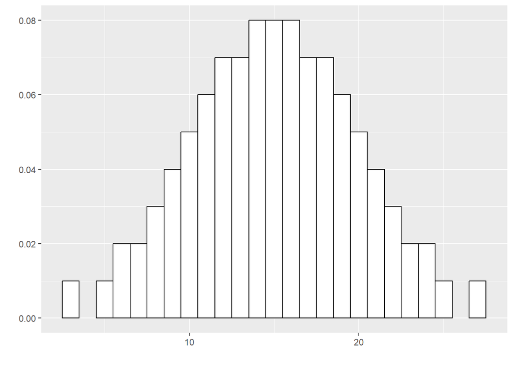

```r
n <- 100; w <- 1
x_bell <- qnorm((1:n)/(n+1), mean=15, sd=5)
draw_histogram(x_bell, w)
```

```r
ggsave("../images/histogram-01.png")
```

## Bell-shaped curve is a limit

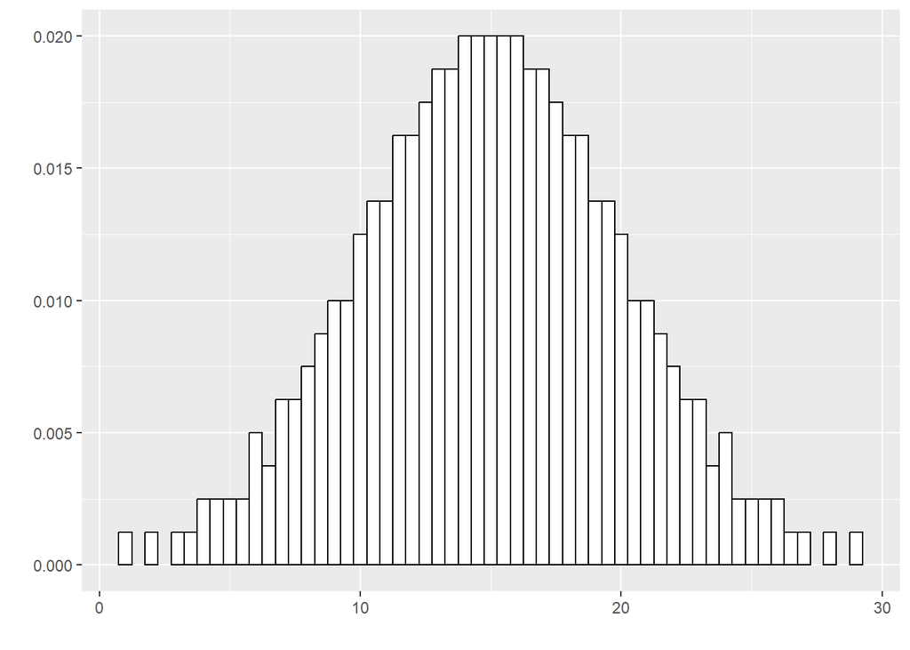

```r
n <- n*4; w <- w/2
x_bell <- qnorm((1:n)/(n+1), mean=15, sd=5)
draw_histogram(x_bell, w)
```

```r
ggsave("../images/histogram-02.png")
```

## Bell-shaped curve is a limit

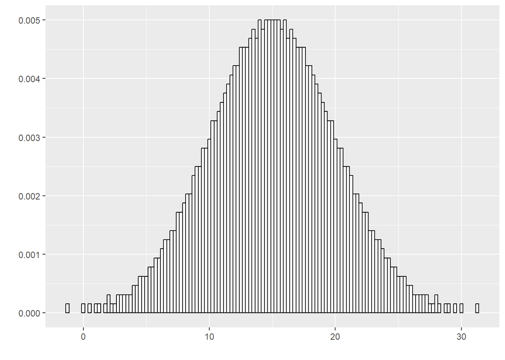

```r
n <- n*4; w <- w/2
x_bell <- qnorm((1:n)/(n+1), mean=15, sd=5)
draw_histogram(x_bell, w)
```

```r
ggsave("../images/histogram-03.png")
```

## Bell-shaped curve is a limit

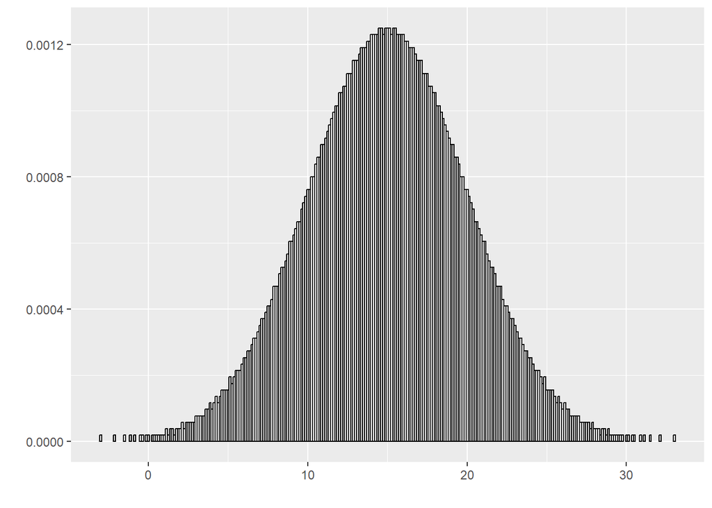

```r
n <- n*4; w <- w/2
x_bell <- qnorm((1:n)/(n+1), mean=15, sd=5)
draw_histogram(x_bell, w)
```

```r
ggsave("../images/histogram-04.png")
```

## Normal distribution with mu=2, sigma=1

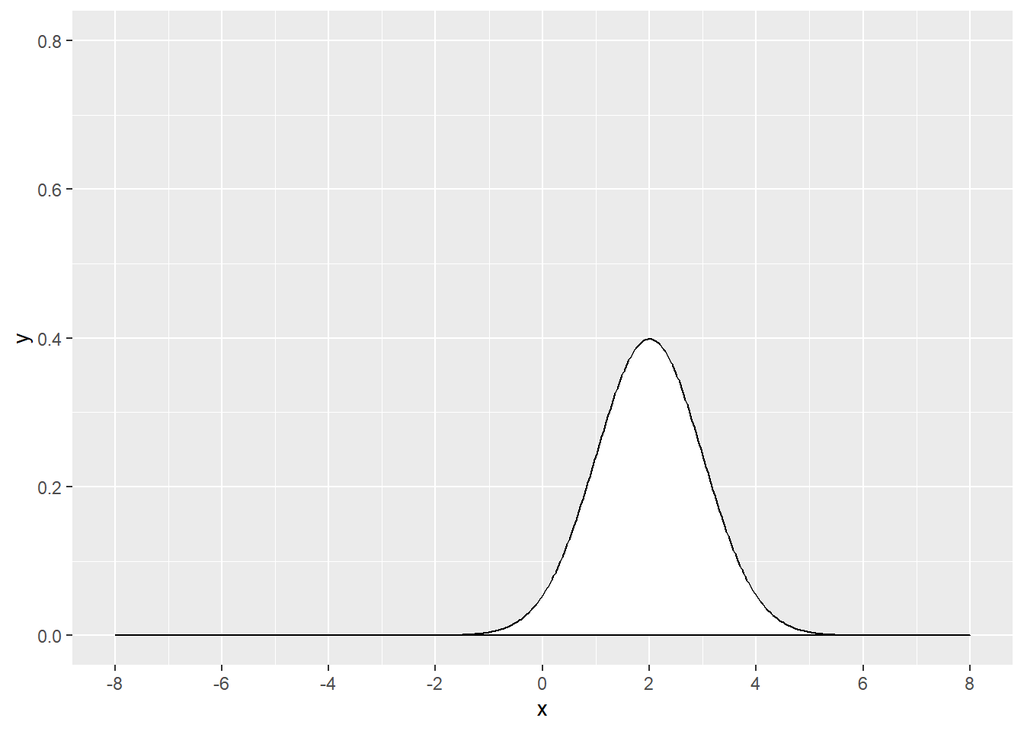

```r
normal_bell(mu=2, sigma=1)
```

```r
ggsave("../images/bell-01.png")
```

## Normal distribution with mu=-3, sigma=1

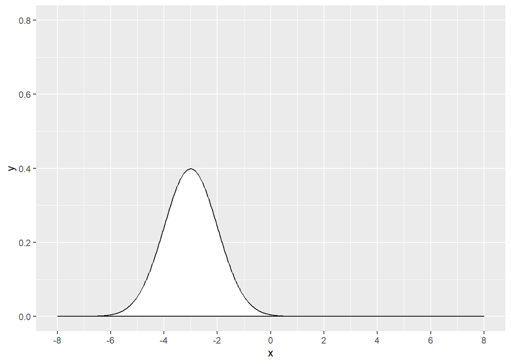

```r
normal_bell(mu=-3, sigma=1)
```

```r
ggsave("../images/bell-02.png")
```

## Normal distribution with mu=1, sigma=1

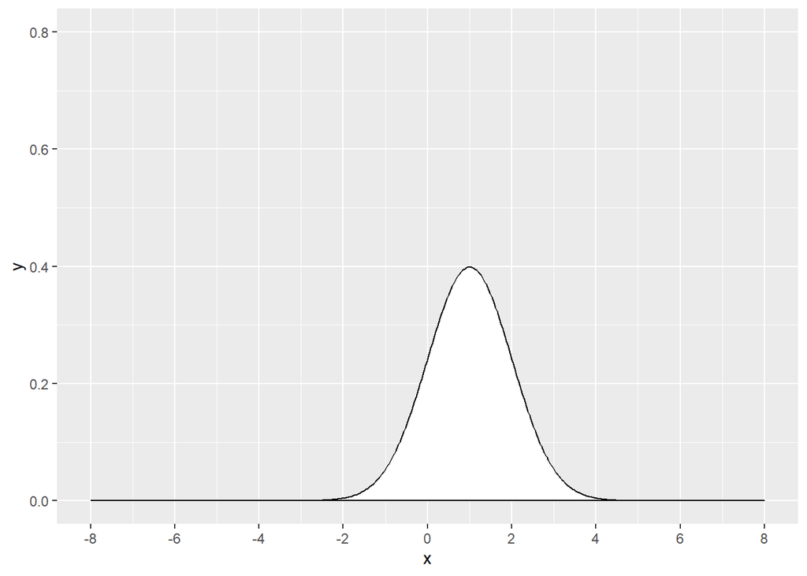

```r
normal_bell(mu=1, sigma=1)
```

```r
ggsave("../images/bell-03.png")
```

## Normal distribution with mu=1, sigma=2

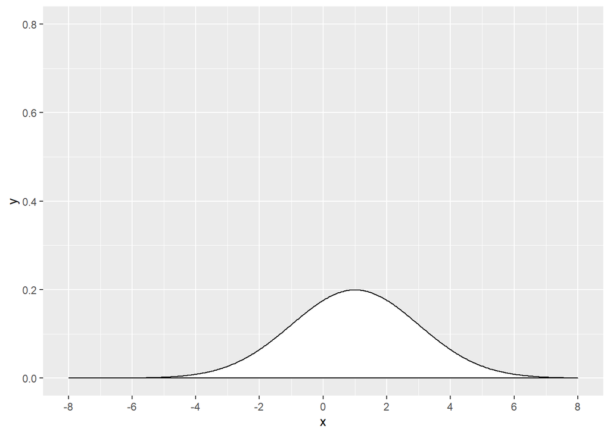

```r
normal_bell(mu=1, sigma=2)
```

```r
ggsave("../images/bell-04.png")
```

## Normal distribution with mu=1, sigma=0.5

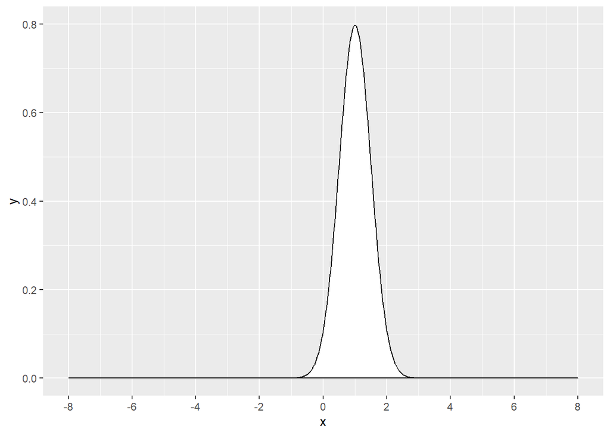

```r
normal_bell(mu=1, sigma=0.5)
```

```r
ggsave("../images/bell-05.png")
```

## Standard normal distribution (mu=0, sigma=1)

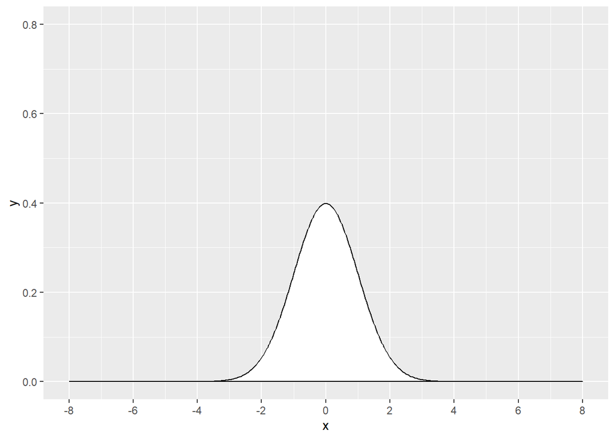

```r
normal_bell()
```

```r
ggsave("../images/bell-06.png")
```

## Using R to draw the standard normal curve

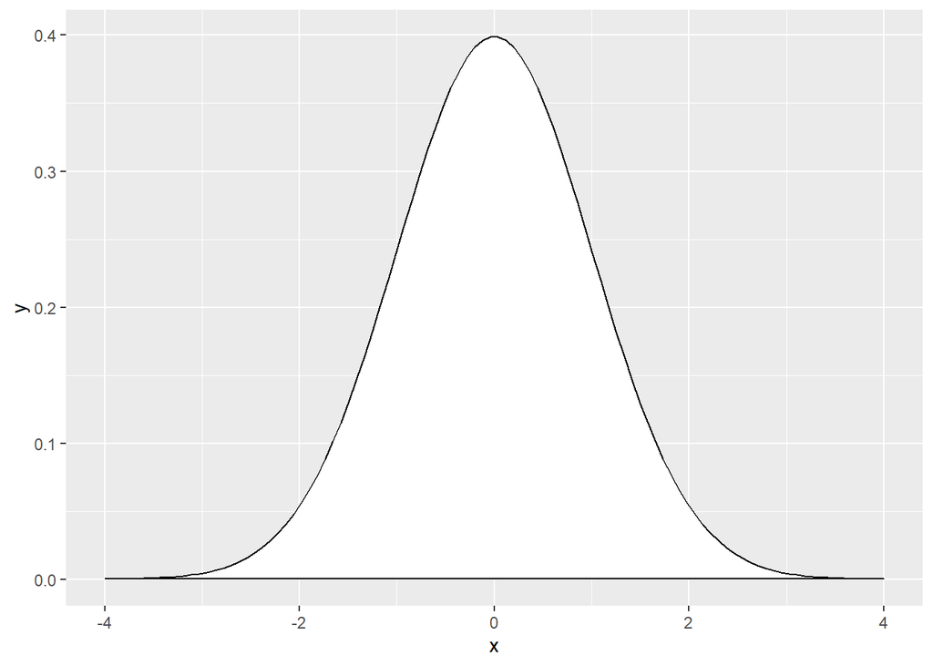

```r
x <- seq(from=-4, to=4, length=100)
y <- dnorm(x)
data.frame(x, y) |>
  ggplot() +
  aes(x, y) +
  geom_polygon(fill="white", color="black") -> normal_curve
normal_curve
```

```r
ggsave("../images/normal-00.png")
```

#### Comments on the code

The [seq function](https://stat.ethz.ch/R-manual/R-devel/RHOME/library/base/html/seq.html), part of base R, calculates evenly spaced values within an interval. The code here calculates 100 evenly spaced values between -4 and +4. The [dnorm function](https://stat.ethz.ch/R-manual/R-devel/library/stats/html/Normal.html) is part of base R and calculates the height of the normal curve. You can specify a mean and standard deviation, but if you leave it out, it specifies the height for a standard normal.

The [ggplot function](https://ggplot2.tidyverse.org/reference/ggplot.html) is part of the [ggplot2 library](https://ggplot2.tidyverse.org/) and included within the tidyverse libary. This function allows you to specify the data for plotting.

The [aes function](https://ggplot2.tidyverse.org/reference/aes.html) is short for aesthetics. It is part of the ggplot2 library and defines which variables are used for axes, color, markers, etc.

The [geom-polygon function](https://ggplot2.tidyverse.org/reference/geom_polygon.html) defines an irregular shape using the X and Y values defined in aes. It allows you to control the style of the border and the color used to fill the polygon.

The [ggsave function](https://ggplot2.tidyverse.org/reference/ggsave.html) is part of the ggplot2 library. It saves the results of a ggplot function as a file. It looks at the extension to decide what format to use.

## P[Z < 1.5]

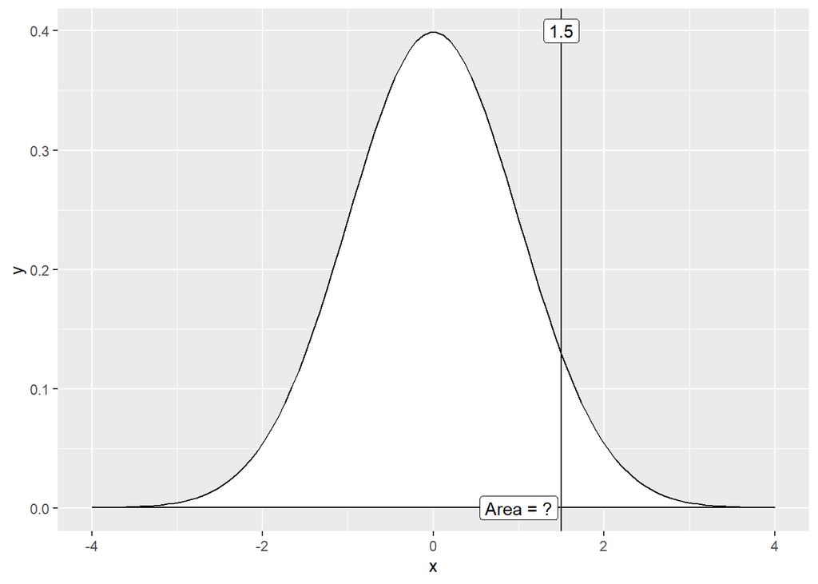

```r
a <- 1.5
normal_curve +
  geom_vline(xintercept=a) +
  geom_label(x=a, y=0.4, label=a) +
  geom_label(x=a-0.5, y=0, label="Area = ?") -> prob1
prob1
```

```r
ggsave("../images/normal-01.png")
pnorm(1.5)
```

```
[1] 0.9331928
```

#### Comments on the code

Use the [geom_vline function](https://ggplot2.tidyverse.org/reference/geom_abline.html) and [geom_label function](https://ggplot2.tidyverse.org/reference/geom_text.html), both part of the ggplot2 library to draw a vertical reference line and add text to the normal curve.

The [pnorm function](https://stat.ethz.ch/R-manual/R-devel/library/stats/html/Normal.html) computes the standard normal probability. The link listed here also describes the qnorm function used later in this program.

#### Interpretation of the output

The probability that a standard normal variable is less than 1.5 is about 93%.

## P[Z < -0.5]

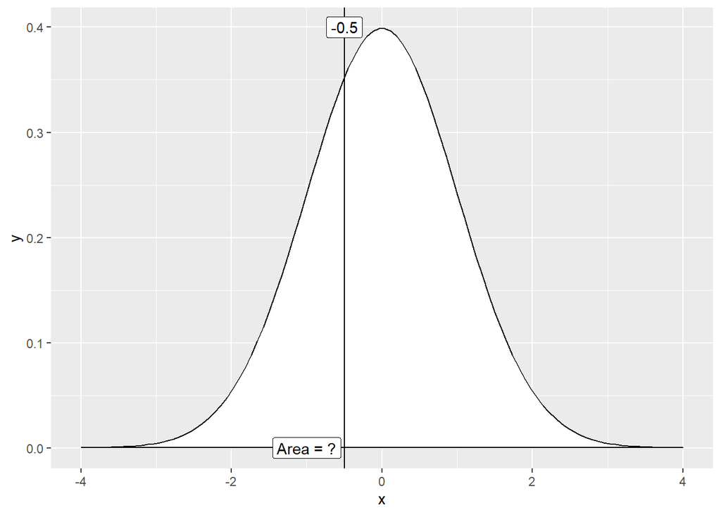

```r
a <- -0.5
normal_curve +
  geom_vline(xintercept=a) +
  geom_label(x=a, y=0.4, label=a) +
  geom_label(x=a-0.5, y=0, label="Area = ?") -> prob2
prob2
```

```r
ggsave("../images/normal-02.png")
pnorm(-0.5)
```

```
[1] 0.3085375
```

#### Interpretation of the output

The probability that a standard normal variable is less than -0.5 is about 31%.

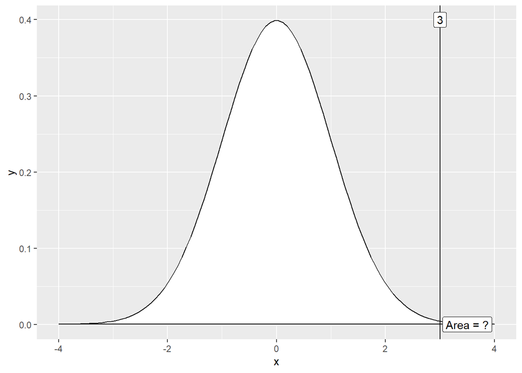

```r
a <- 3
normal_curve +
  geom_vline(xintercept=a) +
  geom_label(x=a, y=0.4, label=a) +
  geom_label(x=a+0.5, y=0, label="Area = ?") -> prob3
prob3
```

```r
ggsave("../images/normal-03.png")
1- pnorm(3)
```

```
[1] 0.001349898
```

#### Comments on the code

When you are calculating the probability on the right (probability greater than some number), use 1-pnorm.

#### Interpretation of the output

The probability that a standard normal variable is larger than 3 is about 0.1%.

## P[Z > -2]

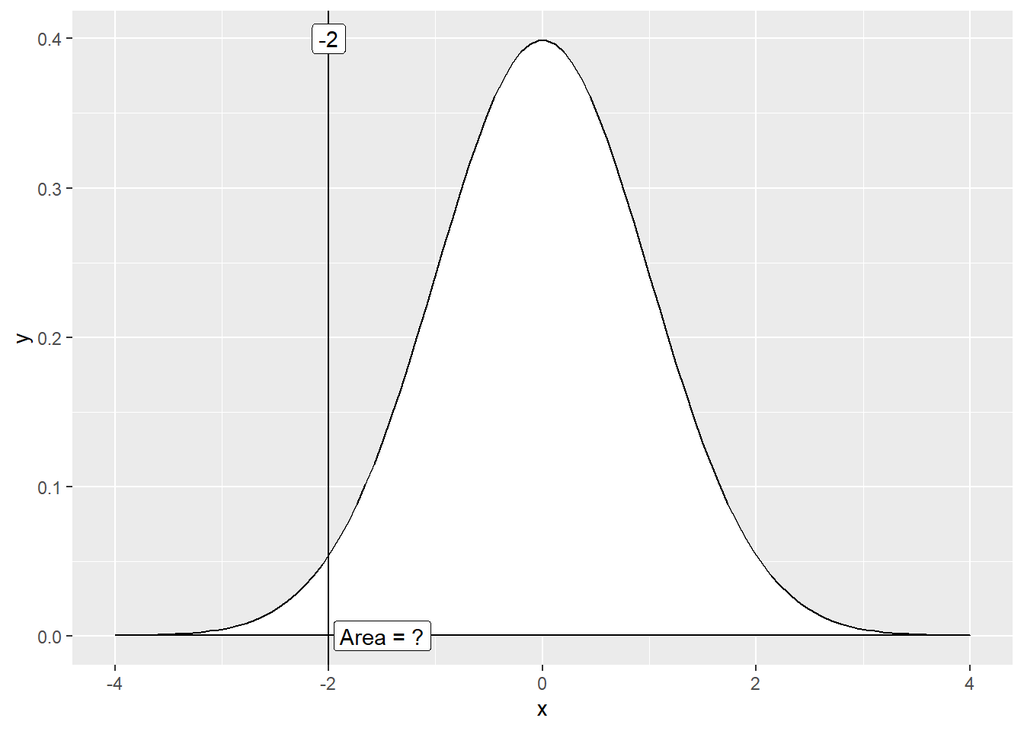

```r
a <- -2
normal_curve +
  geom_vline(xintercept=a) +
  geom_label(x=a, y=0.4, label=a) +
  geom_label(x=a+0.5, y=0, label="Area = ?") -> prob4
prob4
```

```r
ggsave("../images/normal-04.png")
1- pnorm(-2)
```

```
[1] 0.9772499
```

#### Interpretation of the output

The probability that a standard normal variable is larger than -2 is about 98%.

## P[-2.5 < Z < 2.5]

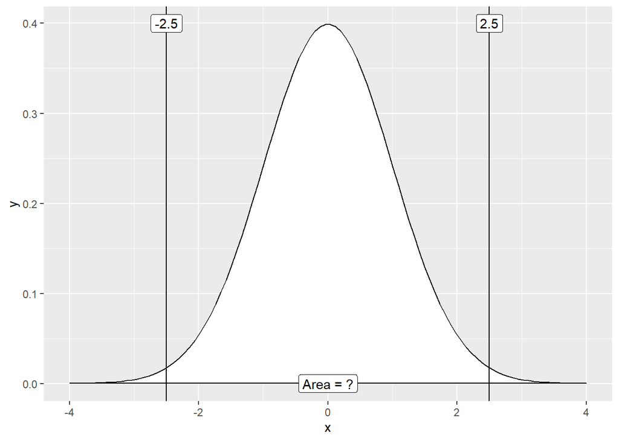

```r
a <- 2.5
normal_curve +
  geom_vline(xintercept=-a) +
  geom_vline(xintercept= a) +
  geom_label(x=-a, y=0.4, label=-a) +
  geom_label(x= a, y=0.4, label= a) +
  geom_label(x=0, y=0, label="Area = ?") -> prob5
prob5
```

```r
ggsave("../images/normal-05.png")
pnorm(2.5)- pnorm(-2.5)
```

```
[1] 0.9875807
```

#### Comments on the code

When you are calculating the probability between two values, compute pnorm of the larger value minus pnorm of the smaller value.

#### Interpretation of the output.

The probability that a standard normal variable is between -2.5 and 2.5 is approximately 99%.

## P[-0.5 < Z < 0.5]

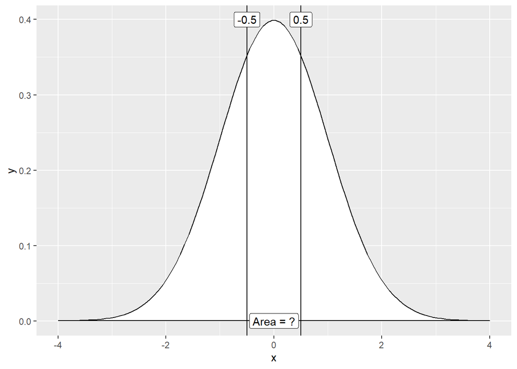

```r
a <- 0.5
normal_curve +
  geom_vline(xintercept=-a) +
  geom_vline(xintercept= a) +
  geom_label(x=-a, y=0.4, label=-a) +
  geom_label(x= a, y=0.4, label= a) +
  geom_label(x=0, y=0, label="Area = ?") -> prob6
prob6
```

```r
ggsave("../images/normal-06.png")
pnorm(0.5) - pnorm(-0.5)
```

```
[1] 0.3829249
```

#### Interpretation of the output

The probability that a standard normal variable is between -0.5 and 0.5 is about 38%.

## 25th percentile of a standard normal

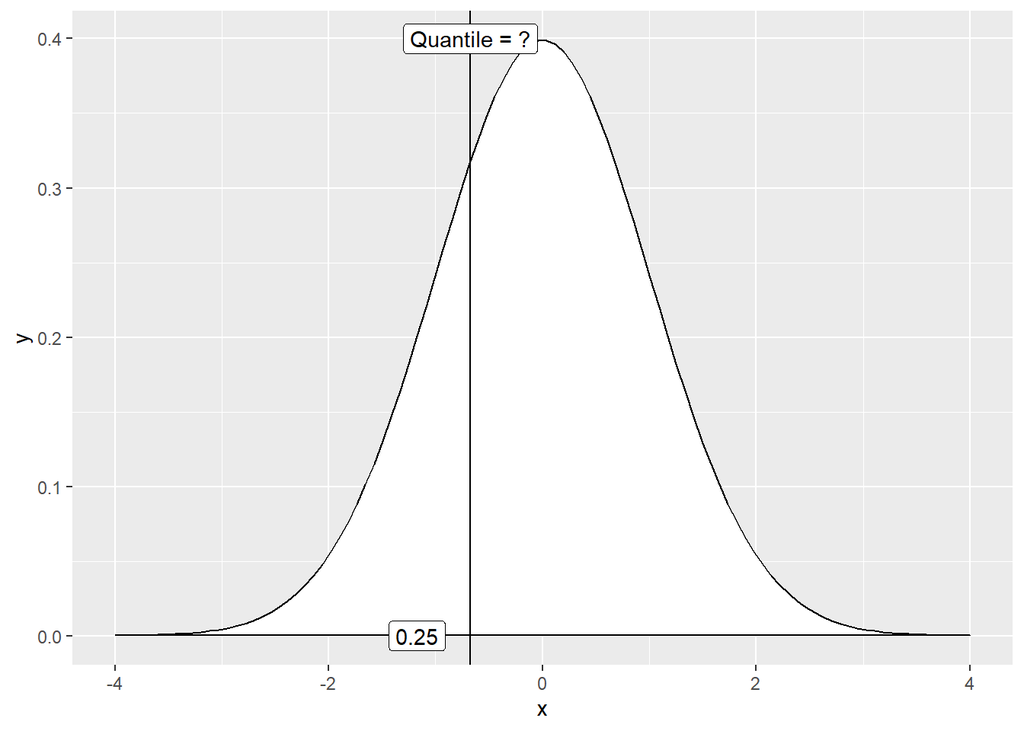

```r
p <- 0.25
a <- qnorm(p)
normal_curve +
  geom_vline(xintercept=a) +
  geom_label(x=a, y=0.4, label="Quantile = ?") +
  geom_label(x=a-0.5, y=0, label=p) -> prob7
prob7
```

```r
ggsave("../images/normal-07.png")
qnorm(0.25)
```

```
[1] -0.6744898
```

#### Comments on the code

Use the qnorm function, part of base R, to calculate quantiles of the standard normal distribution. A description of the qnorm function is included in the link describing the pnorm function.

#### Interpretation of the output

The 25th percentile of a standard normal distribution is -0.67.

## 90th percentile of a standard normal

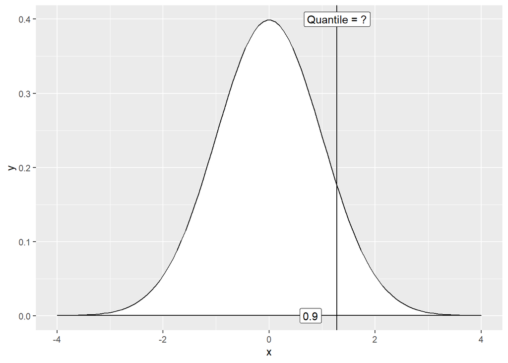

```r
p <- 0.9
a <- qnorm(p)
normal_curve +
  geom_vline(xintercept=a) +
  geom_label(x=a, y=0.4, label="Quantile = ?") +
  geom_label(x=a-0.5, y=0, label=p) -> prob8
prob8
```

```r
ggsave("../images/normal-08.png")
qnorm(0.9)
```

```
[1] 1.281552
```

#### Interpretation of the output

The 90th percentile of a standard normal distribution is 1.28.

## Birthweight calculations

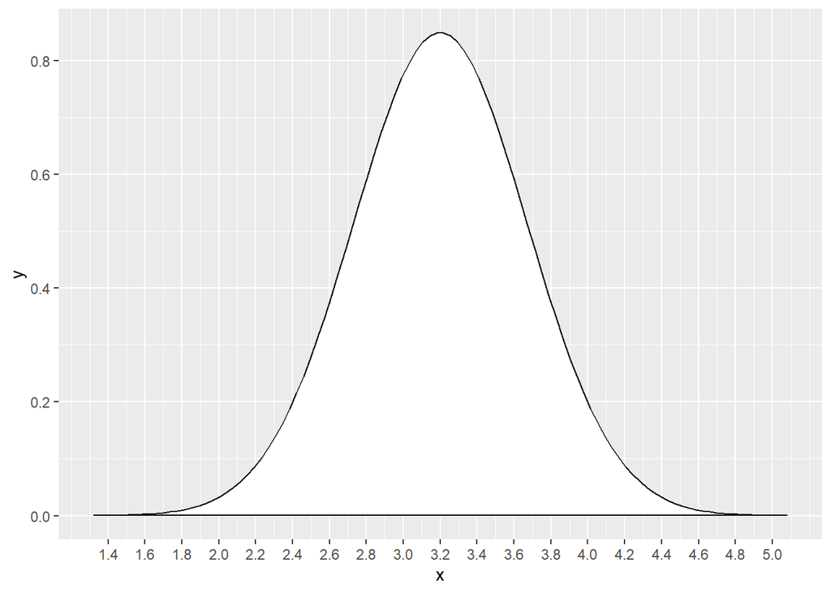

```r
mu <- 3.2
sigma <- 0.47

x <- seq(mu-4*sigma, mu+4*sigma, length=100)
y <- dnorm(x, mu, sigma)

data.frame(x, y) |>
  ggplot() +
  aes(x, y) +
  scale_x_continuous(breaks=seq(1.4, 5.0, by=0.2)) +
  geom_polygon(fill="white", color="black") -> bw
bw
```

```r
ggsave("../images/birthweight-01.png")
```

```r
mu+qnorm(0.9)*sigma
```

```
[1] 3.802329
```

```r
mu+qnorm(0.1)*sigma
```

```
[1] 2.597671
```

```r
pnorm((4-mu)/sigma)
```

```
[1] 0.9556343
```

## Height calculations

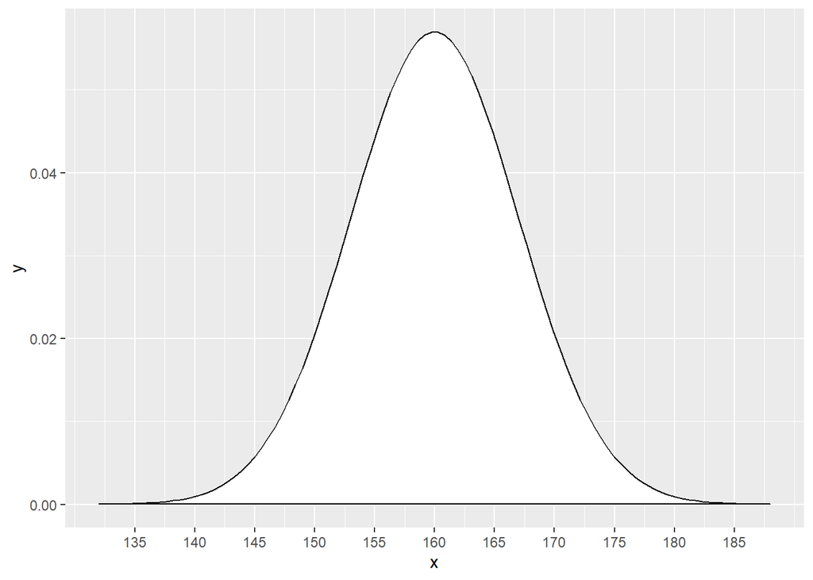

```r
mu <- 160
sigma <- 7

x <- seq(mu-4*sigma, mu+4*sigma, length=100)
y <- dnorm(x, mu, sigma)

data.frame(x, y) |>
  ggplot() +
  aes(x, y) +
  scale_x_continuous(breaks=seq(135, 185, by=5)) +
  geom_polygon(fill="white", color="black") -> bw
bw
```

```r
ggsave("../images/height-01.png")
```